# Laboratory Report - Investigating the role of Nanog during peri-implatation of mouse embryo using scRNA-seq expression analysis

For both datasets the clusters have been tested. The top differentially expressed genes are likely to be good candidate markers as they can effectively distinguish between cells in different clusters. The top markers candidates for cluster 1 of E3.5 (which contains the majority of cells and the largest positive silhouette width) and cluster 2 of E4.5, have been chosen to be visualized on a heatmap, together with the expression profile of some pluripotency markers (Oct4, Nanog, Esrrb, Otx2).

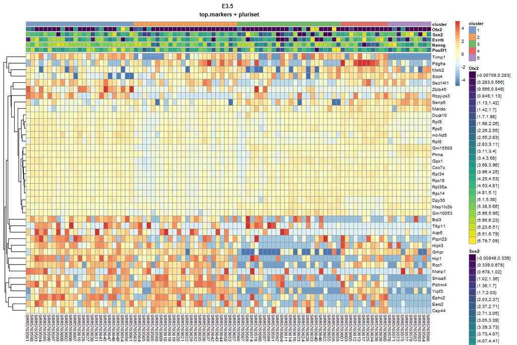

30a

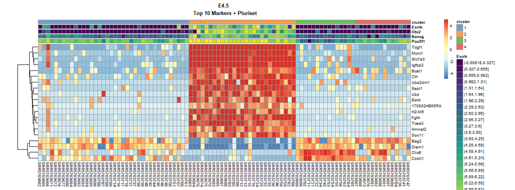

30b

*Fig. 30 - Heatmap of mean-centred and normalized log-expression values for the top set of markers for cluster 1 in the E3.5 dataset. Markers of pluripotency and lineage differentiation are also added on top rows.*

While no pattern is recognizable on the heatmap for E3.5, the expression profiles for the markers for cluster 2 of E4.5 dataset result strongly associated to a subpopulation of cells expressing typical features of the epiblast phenotype.

This is in accordance to the biological knowledge on the embryo development. As reported in the original study, at stage E3.5 transcriptional variability occurring in the inner cell mass (ICM) in the absence of cell-type substructure indicates the existence of uncoordinated transcriptional heterogeneity or transcriptional noise (Mohammed et al. 2017). But this also confirms previous findings that genes specific of PrE (Gata6, Sox17) and epiblast (Nanog, Sox2) initially result co-expressed in cells within the E3.5 ICM before becoming restricted to specific cell types by E4.5 (Ohnishi et al. 2014).

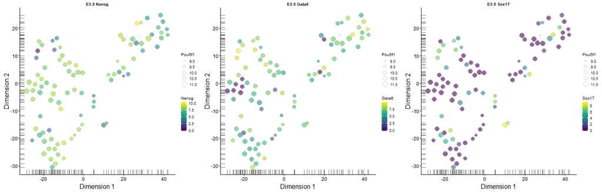

31a

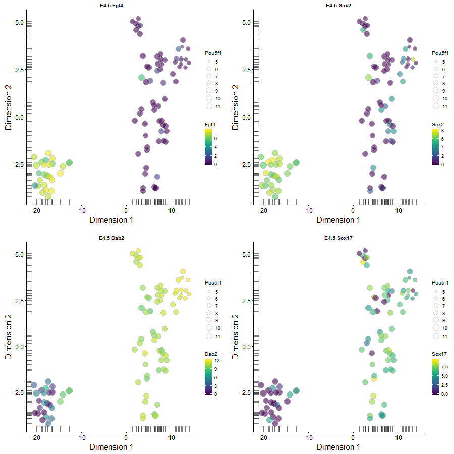

31b

*Fig. 31 - t-SNE plot comparison between E3.5 and E4.5 datasets showing the expression distribution of epiblast and primitive endoderm markers across the cells.*

It is also known by studies exploring the cooperation of transcription factors in PrE induction in ESCs, that Sox17/Oct4 partner to co-select specific target genes during commitment to primitive endoderm (Aksoy et al. 2013). A model has been proposed. In pluripotent cells, Oct4 and Sox2 expression levels being high, both factors cooperate and target speci???cally the canonical motif to regulate the expression of genes involved in self-renewal and pluripotency (e.g., Nanog). When these cells are subjected to an endodermal differentiation signal such as FGF4 within the ICM, Sox17 levels increase leading to a switch of Oct4 from an interaction with Sox2 to an interaction with Sox17, and thereby targets speci???c genes containing a compressed motif to trigger the endodermal expression program. The expression profile of these genes across the stages E3.5 and E4.5 in this dataset seems to confirm this model (Fig. 31), supporting the hypotesis that the cluster 2 identified by tSNE at stage E4.5 correspond to the epiblast cell type.

It’s also important to notice that Esrrb is included among the top markers of cluster 2 showing an expression profile very similar to Nanog and others pluripotency genes on the dataset. Among the Nanog target genes identified by using a Nanog knockout system on mouse ESCs, Esrrb showed the strongest transcriptional induction. Moreover the existance of partial funcional overlap between Nanog and Esrrb has been proposed (Festuccia et al. 2012).

On the next step the attention has been focused on the genes that are driving heterogeneity across the population of cells, by identifying highly variable genes (HVGs): those genes with the largest biological components of the variance in expression. In order to distinguish between HVGs caused by random noise and those involved in driving systematic differences between subpopulations, gene pairs with significantly positive or negative correlation have been quantified by computing Spearman’s rho(rho = 1 means a perfect positive correlation and the value rho = -1 means a perfect negataive correlation), which accommodates non-linear relationships in the expression values, therefore has been preferred to the classical Pearson’s correlation coefficients. On the E3.5 dataset only 12 out of 2601 significantly correlated genes pairs (FDR <= 5%) include Nanog, while 341 out of 119754 genes resulted significantly correlated to Nanog in the E4.5 dataset.

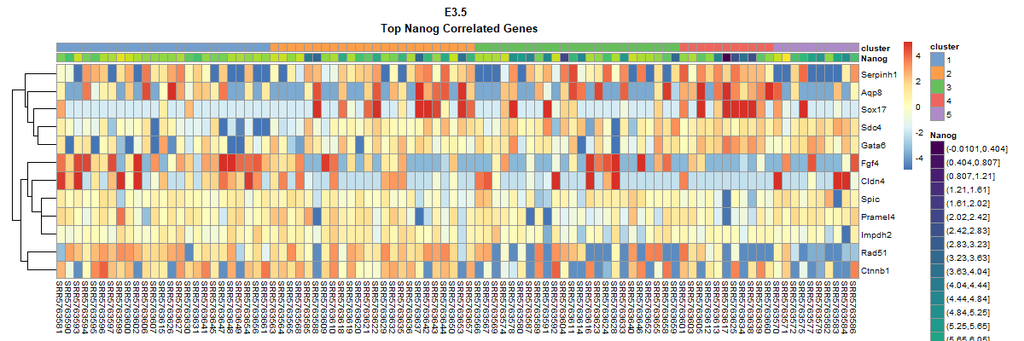

32a

[figure not shown]

32b

*Fig. 32 - Heatmap of mean-centred and normalized log-expression values for the top HVGs correlated to Nanog in the E3.5 and E4.5 datasets*

Among the list of genes positively correlated to Nanog at stage E3.5 it’s important to report Rad51 (rho = 0.42), a key component of the DNA double-strand breaks repair through homologous recombination and has been shown to increase the reprogramming efficiency during the generation of induced pluripotent stem cells by facilitating mesenchymal-to-epithelial transition during the early phase of the reprogramming process (J.-Y. Lee et al. (2016)), and Fgf4 (rho = 0.39), which contributes to the ICM lineage segregation (Ohnishi et al. 2014). Notably, Sox17 and Gata6 results negatively correlated to Nanog (rho = -0.41 / -0.36), anticipating the emergence of these two TFs among the PrE precursors at stage E4.5.

The same correletion pattern can in fact been found on the list of Nanog correlatet genes at stage E4.5, with Gata6 showing a stronger negative association (rho = -0.54) on conjunction with specific PrE phenotype markers like Dab2 (rho = -0.71) and Sox17 (rho = -0.44). Observing the heatmap on figure 32b it is possible to spot a group of genes with high positive correlation to Nanog overlapping with the top marker genes used to define the cluster 2 on the previous step (Tdgf1, Morc1, Slc7a3, Igfbp2) attributable to the epiblast subpopulation. The presence of Esrrb within the Nanog correlated genes (rho = 0.57) and its coexpression with Nanog in the epiblast subpopulation confirms the functional overlap observed in the ESCs model (Festuccia et al. 2012).

It’s also curious to notice at this stage, a positive correlation between Nanog and Otx2 (rho = 0.49) showing a similar expression profile characterized by high levels in the epiblast subpopulation (see Fig. 30b). Nanog is a direct target of Otx2 and previous studies suggested how Otx2 regulation of Nanog contributes to ICM differentiation of the epiblast, observing that stage E4.5 is characterized by contemporary and frequently complementary expression of Nanog and Otx2, resembling the identity of ESCs cultured in LIF/FBS (Acampora et al. 2016), where through mutual antagonism, these TFs specify the heterogeneous identity of ESCs predisposing them for optimal response to naive or primed inducing factors (Acampora et al. 2017).

More than 300 genes resulted significantly correlated to Nanog at stage E4.5. In order to understand which of these genes is driving the specification of the epiblast, the downstream analyais has been focused only on the cluster 2, subsetting the dataset to include only cells showing elevated expression for Oct4 and others naive pluripotency markers. However the Searman’s rank correlation performed on this subset produced correlated a list of gene pair with a low significance (FDR greater than 35%) which cannot lead to strong biological conclusions.

At the end of the study a transcription level comparison has been berformed, without summarizing the expression at gene level, in order to get some insights into the distribution of expression profile among the trascripts of interesting genes.

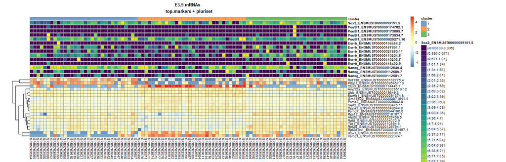

33a

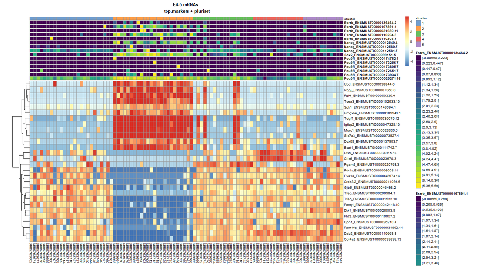

33b

*Fig. 33 - Heatmap of mean-centred and normalized log-expression values for the top set of markers transcripts for E3.5 and E4.5 dataset. Marker transcripts of pluripotency and lineage differentiation are also added on top rows.*

Surprisingly, many alternative spliced variants for the naive pluripotency genes can be observed with this approach, as well as their differential expression profile. Six protein-coding transcripts were detected for Oct4 but only one able of biological function (ENSMUST00000025271.16).

The mouse Esrrb gene has six coding exons, with evidence for six alternatively spliced Esrrb mRNAs in the ENSEMBL EST databases, but one of them is not protein coding (ENSMUST00000136464.2). the abundance for all the six isoforms have been quantified by kallisto and the most abundant transcripts on the E4.5 stage is Esrrb-203 (ENSMUST00000110204.8, total logcounts = 170.7892) followed by Esrrb-206 (ENSMUST00000167891.1, total logcounts = 104.4746).

To understand the biological relationship among these alternative transcripts, the Spearman’s rho has been computed to find correlate pairs on the E4.5 dataset.

| gene1 | gene2 | rho | p.value | FDR | limited |
| --- | --- | --- | --- | --- | --- |
| Nanog_ENSMUST00000112581.7 | Nanog_ENSMUST00000112580.7 | 0.8539898 | 0.000002 | 0.0000560 | TRUE |
| Nanog_ENSMUST00000112580.7 | Nanog_ENSMUST00000012540.4 | -0.4036484 | 0.000076 | 0.0009100 | FALSE |
| Nanog_ENSMUST00000012540.4 | Esrrb_ENSMUST00000110204.8 | 0.3988224 | 0.000102 | 0.0009100 | FALSE |
| Esrrb_ENSMUST00000110204.8 | Esrrb_ENSMUST00000167891.1 | 0.3919734 | 0.000130 | 0.0009100 | FALSE |
| Nanog_ENSMUST00000012540.4 | Esrrb_ENSMUST00000167891.1 | 0.3686378 | 0.000338 | 0.0017733 | FALSE |
| Nanog_ENSMUST00000112581.7 | Nanog_ENSMUST00000012540.4 | -0.3643608 | 0.000380 | 0.0017733 | FALSE |
| Nanog_ENSMUST00000112580.7 | Esrrb_ENSMUST00000167891.1 | -0.2687209 | 0.009362 | 0.0374480 | FALSE |

*Fig. 34 - Spearman’s rank correlate pairs computed for Nanog and Esrrb variants within the E4.5 dataset.*

# Conclusions

Other studies analyzed the effect of acute depletion of Oct4 or Nanog, in order to understand the mechanisms underlying the transcriptional modulation of the naive pluripotency of ESCs (Hall et al. 2009),(Festuccia et al. 2012).

Less studies however have been carried out on the embryo.

The list of Nanog correlated genes identified in this single-cell dataset for the stages E3.5 and E4.5 of the mouse embryo development, will be used for a comparison study to a set of 64 genes responding to Nanog identified using an ESCs Nanog -/- model (Festuccia et al. 2012). The Spearman’s rank correlation coefficient assigned to each gene will be used to discover the strength of a link between two sets of data. As a control for this comparison the expression variation of Esrrb in correlation with Nanog will be used as reference, being Esrrb reported experimentally to have the strongest transcriptional induction as a result of Nanog binding (Festuccia et al. 2012).

If the in-vitro ESCs Nanog -/- model will be proven to be consistent with the embryo expression analysis reported here, this study will hopefully lead to a better understanding of the pluripotency gene regulatory network.

# Bibliography

Acampora, Dario, Luca Giovanni Di Giovannantonio, Arcomaria Garofalo, Vincenzo Nigro, Daniela Omodei, Alessia Lombardi, Jingchao Zhang, Ian Chambers, and Antonio Simeone. 2017. “Functional Antagonism Between OTX2 and NANOG Specifies a Spectrum of Heterogeneous Identities in Embryonic Stem Cells.” *Stem Cell Reports* 9 (5): 1642–59. doi:10.1016/j.stemcr.2017.09.019.

Acampora, Dario, Daniela Omodei, Giuseppe Petrosino, Arcomaria Garofalo, Marco Savarese, Vincenzo Nigro, Luca Giovanni Di Giovannantonio, Vincenzo Mercadante, and Antonio Simeone. 2016. “Loss of the Otx2-Binding Site in the Nanog Promoter Affects the Integrity of Embryonic Stem Cell Subtypes and Specification of Inner Cell Mass-Derived Epiblast.” *Cell Reports* 15 (12): 2651–64. doi:10.1016/j.celrep.2016.05.041.

Aksoy, Irene, Ralf Jauch, Jiaxuan Chen, Mateusz Dyla, Ushashree Divakar, Gireesh K. Bogu, Roy Teo, et al. 2013. “Oct4 Switches Partnering from Sox2 to Sox17 to Reinterpret the Enhancer Code and Specify Endoderm.” *The EMBO Journal* 32 (7): 938–53. doi:10.1038/emboj.2013.31.

Andrews, Simon. 2018. “FastQC - a Quality Control Tool for High Throughput Sequence Data. Babraham Bioinformatics.” January 10. http://www.bioinformatics.babraham.ac.uk/projects/fastqc/.

Boyer, Laurie A., Tong Ihn Lee, Megan F. Cole, Sarah E. Johnstone, Stuart S. Levine, Jacob P. Zucker, Matthew G. Guenther, et al. 2005. “Core Transcriptional Regulatory Circuitry in Human Embryonic Stem Cells.” *Cell* 122 (6): 947–56. doi:10.1016/j.cell.2005.08.020.

Bray, Nicolas L., Harold Pimentel, Páll Melsted, and Lior Pachter. 2016. “Near-Optimal Probabilistic RNA-Seq Quantification.” *Nature Biotechnology* 34 (5): 525–27. doi:10.1038/nbt.3519.

Chambers, Ian, Douglas Colby, Morag Robertson, Jennifer Nichols, Sonia Lee, Susan Tweedie, and Austin Smith. 2003. “Functional Expression Cloning of Nanog, a Pluripotency Sustaining Factor in Embryonic Stem Cells.” *Cell* 113 (5): 643–55. doi:10.1016/S0092-8674(03)00392-1.

Chambers, Ian, Jose Silva, Douglas Colby, Jennifer Nichols, Bianca Nijmeijer, Morag Robertson, Jan Vrana, Ken Jones, Lars Grotewold, and Austin Smith. 2007. “Nanog Safeguards Pluripotency and Mediates Germline Development.” *Nature* 450 (7173): 1230–4. doi:10.1038/nature06403.

Chen, Xi, Han Xu, Ping Yuan, Fang Fang, Mikael Huss, Vinsensius B. Vega, Eleanor Wong, et al. 2008. “Integration of External Signaling Pathways with the Core Transcriptional Network in Embryonic Stem Cells.” *Cell* 133 (6): 1106–17. doi:10.1016/j.cell.2008.04.043.

Das, Satyabrata, Snehalata Jena, and Dana N. Levasseur. 2011. “Alternative Splicing Produces Nanog Protein Variants with Different Capacities for Self-Renewal and Pluripotency in Embryonic Stem Cells.” *Journal of Biological Chemistry* 286 (49): 42690–42703. doi:10.1074/jbc.M111.290189.

Everaert, Celine, Manuel Luypaert, Jesper L. V. Maag, Quek Xiu Cheng, Marcel E. Dinger, Jan Hellemans, and Pieter Mestdagh. 2017. “Benchmarking of RNA-Sequencing Analysis Workflows Using Whole-Transcriptome RT-qPCR Expression Data.” *Scientific Reports* 7 (1): 1559. doi:10.1038/s41598-017-01617-3.

Ewels, Philip, Måns Magnusson, Sverker Lundin, and Max Käller. 2016. “MultiQC: Summarize Analysis Results for Multiple Tools and Samples in a Single Report.” *Bioinformatics* 32 (19): 3047–8. doi:10.1093/bioinformatics/btw354.

Festuccia, Nicola, Rodrigo Osorno, Florian Halbritter, Violetta Karwacki-Neisius, Pablo Navarro, Douglas Colby, Frederick Wong, Adam Yates, Simon R. Tomlinson, and Ian Chambers. 2012. “Esrrb Is a Direct Nanog Target Gene That Can Substitute for Nanog Function in Pluripotent Cells.” *Cell Stem Cell* 11 (4): 477–90. doi:10.1016/j.stem.2012.08.002.

Grüning, Björn, Ryan Dale, Andreas Sjödin, Brad A. Chapman, Jillian Rowe, Christopher H. Tomkins-Tinch, Renan Valieris, and Johannes Köster. 2018. “Bioconda: Sustainable and Comprehensive Software Distribution for the Life Sciences.” *Nature Methods* 15 (7): 475–76. doi:10.1038/s41592-018-0046-7.

Hall, John, Ge Guo, Jason Wray, Isobel Eyres, Jennifer Nichols, Lars Grotewold, Sofia Morfopoulou, et al. 2009. “Oct4 and LIF/Stat3 Additively Induce Krüppel Factors to Sustain Embryonic Stem Cell Self-Renewal.” *Cell Stem Cell* 5 (6): 597–609. doi:10.1016/j.stem.2009.11.003.

Huber, Wolfgang, Vincent J. Carey, Robert Gentleman, Simon Anders, Marc Carlson, Benilton S. Carvalho, Hector Corrada Bravo, et al. 2015. “Orchestrating High-Throughput Genomic Analysis with Bioconductor.” *Nature Methods* 12 (2): 115–21. doi:10.1038/nmeth.3252.

Ilicic, Tomislav, Jong Kyoung Kim, Aleksandra A. Kolodziejczyk, Frederik Otzen Bagger, Davis James McCarthy, John C. Marioni, and Sarah A. Teichmann. 2016. “Classification of Low Quality Cells from Single-Cell RNA-Seq Data.” *Genome Biology* 17 (1): 29. doi:10.1186/s13059-016-0888-1.

Islam, Saiful, Amit Zeisel, Simon Joost, Gioele La Manno, Pawel Zajac, Maria Kasper, Peter Lönnerberg, and Sten Linnarsson. 2014. “Quantitative Single-Cell RNA-Seq with Unique Molecular Identifiers.” *Nature Methods* 11 (2): 163–66. doi:10.1038/nmeth.2772.

Krueger, Felix. 2018. “Trim Galore! Babraham Bioinformatics.” June 28. https://www.bioinformatics.babraham.ac.uk/projects/trim_galore/.

Langfelder, Peter, and Steve Horvath. 2008. “WGCNA: An R Package for Weighted Correlation Network Analysis.” *BMC Bioinformatics* 9 (1): 559. doi:10.1186/1471-2105-9-559.

Lee, Jae-Young, Dae-Kwan Kim, Jeong-Jae Ko, Keun Pil Kim, and Kyung-Soon Park. 2016. “Rad51 Regulates Reprogramming Efficiency Through DNA Repair Pathway.” *Development & Reproduction* 20 (2): 163–69. doi:10.12717/DR.2016.20.2.163.

Lun, Aaron. 2018. “Scran - Methods for Single-Cell RNA-Seq Data Analysis. Bioconductor.” July 17. http://bioconductor.org/packages/scran/.

Lun, Aaron T. L., Davis J. McCarthy, and John C. Marioni. 2018. “simpleSingleCell - a Step-by-Step Workflow for Low-Level Analysis of Single-Cell RNA-Seq Data with Bioconductor. Bioconductor.” May 25. http://bioconductor.org/packages/simpleSingleCell/.

Maaten, Laurens van der, and Geoffrey Hinton. 2008. “Visualizing Data Using T-SNE.” *Journal of Machine Learning Research* 9 (Nov): 2579–2605. http://www.jmlr.org/papers/v9/vandermaaten08a.html.

McCarthy, Davis J., Kieran R. Campbell, Aaron T. L. Lun, and Quin F. Wills. 2017. “Scater: Pre-Processing, Quality Control, Normalization and Visualization of Single-Cell RNA-Seq Data in R.” *Bioinformatics* 33 (8): 1179–86. doi:10.1093/bioinformatics/btw777.

Mohammed, Hisham, Irene Hernando-Herraez, Aurora Savino, Antonio Scialdone, Iain Macaulay, Carla Mulas, Tamir Chandra, et al. 2017. “Single-Cell Landscape of Transcriptional Heterogeneity and Cell Fate Decisions During Mouse Early Gastrulation.” *Cell Reports* 20 (5): 1215–28. doi:10.1016/j.celrep.2017.07.009.

Moore, R., W. Tao, E. R. Smith, and X.-X. Xu. 2014. “The Primitive Endoderm Segregates from the Epiblast in 1 Integrin-Deficient Early Mouse Embryos.” *Molecular and Cellular Biology* 34 (3): 560–72. doi:10.1128/MCB.00937-13.

Muñoz Descalzo Silvia, RuÉ Pau, Garcia‐Ojalvo Jordi, and Arias Alfonso Martinez. 2012. “Correlations Between the Levels of Oct4 and Nanog as a Signature for Naïve Pluripotency in Mouse Embryonic Stem Cells.” *STEM CELLS* 30 (12): 2683–91. doi:10.1002/stem.1230.

Ohnishi, Yusuke, Wolfgang Huber, Akiko Tsumura, Minjung Kang, Panagiotis Xenopoulos, Kazuki Kurimoto, Andrzej K. Oleś, et al. 2014. “Cell-to-Cell Expression Variability Followed by Signal Reinforcement Progressively Segregates Early Mouse Lineages.” *Nature Cell Biology* 16 (1): 27–37. doi:10.1038/ncb2881.

Oliveri, Paola, Qiang Tu, and Eric H. Davidson. 2008. “Global Regulatory Logic for Specification of an Embryonic Cell Lineage.” *Proceedings of the National Academy of Sciences* 105 (16): 5955–62. doi:10.1073/pnas.0711220105.

Ptashne, M., and A. Gann. 2001. “Transcription Initiation: Imposing Specificity by Localization.” *Essays in Biochemistry* 37: 1–15.

Ritchie, Matthew E., Belinda Phipson, Di Wu, Yifang Hu, Charity W. Law, Wei Shi, and Gordon K. Smyth. 2015. “Limma Powers Differential Expression Analyses for RNA-Sequencing and Microarray Studies.” *Nucleic Acids Research* 43 (7): e47–e47. doi:10.1093/nar/gkv007.

Scialdone, Antonio, Kedar N. Natarajan, Luis R. Saraiva, Valentina Proserpio, Sarah A. Teichmann, Oliver Stegle, John C. Marioni, and Florian Buettner. 2015. “Computational Assignment of Cell-Cycle Stage from Single-Cell Transcriptome Data.” *Methods*, Inferring gene regulatory interactions from quantitative high-throughput measurements, 85 (September): 54–61. doi:10.1016/j.ymeth.2015.06.021.

Tam, Patrick P. L., and David A. F. Loebel. 2007. “Gene Function in Mouse Embryogenesis: Get Set for Gastrulation.” *Nature Reviews Genetics* 8 (5): 368–81. doi:10.1038/nrg2084.